# Turn restrictions on toy networks

How OpenTripPlanner, OSRM, GraphHopper and this project apply OSM turn restrictions

```r
source("checks/schematic_helpers.R")
tt1 <- function(net) list(tt = rep(1, nrow(st_as_sf(net, "edges"))))
none <- toy_restrictions(list(id = 9, restriction = "no_entry",
                              from = 99, via = 99, to = 99, via_type = "node"))
```

## How to read the figures

- **Road network** (primal graph): circles are junctions, arrows are directed edges. A two-way street is two arrows, one per direction, driving on the right.
- **Line graph** (edge-based graph): each road edge becomes a vertex (a circle at the middle of the edge) and each **turn** becomes an arrow between two vertices, drawn through the junction where it happens. Dashed grey arrows are U-turns.
- Colours: **from**, **via**, **to**, **copy** (a duplicated node, vertex or edge) and **removed, forbidden or wrong** movements.
- Line graphs are the output of `build_line_graph()` in `processing/line_graph.R`, run on each toy network. OSRM’s edge-based graph has the same structure, so it is drawn with the same function. The OpenTripPlanner and GraphHopper steps are reproduced from their source code for illustration.

## 1. Turn restrictions in OSM

An OSM turn restriction is a relation with a `from` way, a `to` way and a `via` member. The `via` is either a **node** (the junction where the turn happens) or one or more **ways** (the restriction covers a sequence of roads).

```r
# Four-way junction: no_left_turn from the south arm onto the west arm
cross <- toy_network(
  nodes = data.frame(id = 1:5, x = c(0, 0, 1, 0, -1), y = c(0, 1, 0, -1, 0),
                     label = c("C", "N", "E", "S", "W")),
  links = data.frame(way = 11:14, a = c(4, 1, 1, 1), b = c(1, 2, 3, 5),
                     oneway = FALSE, fwd = c("SC", "CN", "CE", "CW"),
                     bwd = c("CS", "NC", "EC", "WC"))
)
r_left <- toy_restrictions(list(id = 1, restriction = "no_left_turn",
                                from = 11, via = 1, to = 14, via_type = "node"))
roles_left <- c(SC = "from", CW = "to")

# Dual carriageway with a median crossover V: no_u_turn A -> V -> B.
# Traffic from the side road X may still cross through V and go south on B.
dual <- toy_network(
  nodes = data.frame(id = 1:8,
                     x = c(0, 0, 0, 0.9, 0.9, 0.9, -1, 1.9),
                     y = c(-1.2, 0, 1.2, 1.2, 0, -1.2, 0, 0),
                     label = c("a", "p", "n", "s", "q", "b", "w", "e")),
  links = data.frame(
    way = c(21, 22, 24, 25, 23, 26, 27),
    a = c(1, 2, 4, 5, 2, 7, 5), b = c(2, 3, 5, 6, 5, 2, 8),
    oneway = c(TRUE, TRUE, TRUE, TRUE, TRUE, FALSE, FALSE),
    fwd = c("A", "N", "S", "B", "V", "X", "Y"),
    bwd = c(NA, NA, NA, NA, NA, "x", "y"))
)
r_uturn <- toy_restrictions(list(id = 1, restriction = "no_u_turn",
                                 from = 21, via = 23, to = 25, via_type = "way"))
roles_uturn <- c(A = "from", V = "via", B = "to")
```

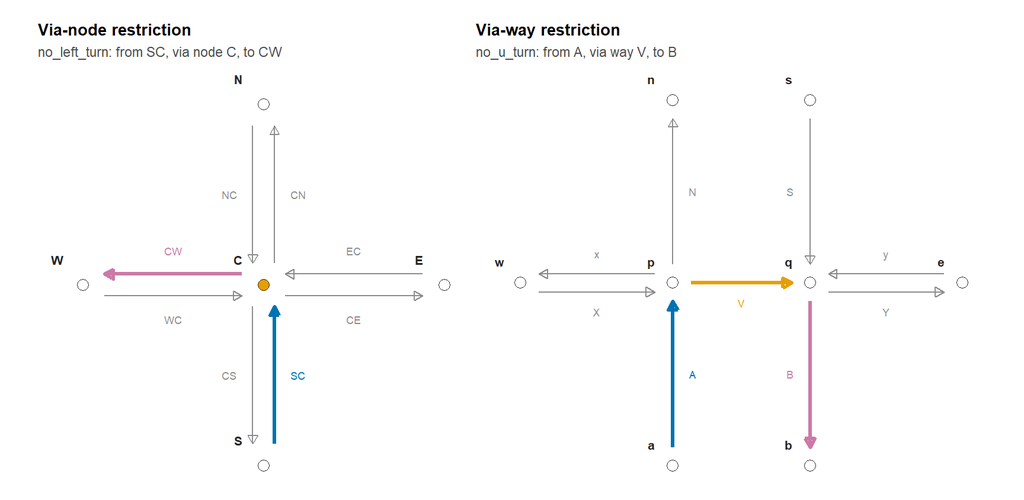

```r
plot_primal(cross, "Via-node restriction", "no_left_turn: from SC, via node C, to CW",
            roles = roles_left, node_roles = c(C = "via")) |
  plot_primal(dual, "Via-way restriction", "no_u_turn: from A, via way V, to B",
              roles = roles_uturn)
```

A via-node restriction bans a single turn. A via-way restriction bans a **sequence**: `A → V → B` is banned, but `X → V → B` is allowed, so no single turn can be deleted on its own.

## 2. Graph structures

The approaches differ first in which graph they store and which graph the search moves along. The same junction, with the `no_left_turn` from `SC` to `CW`, in the three structures:

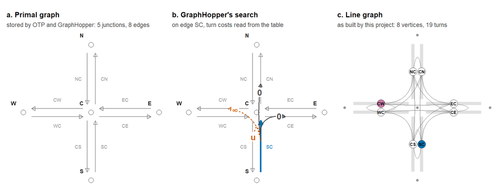

```r
n_nodes <- nrow(st_as_sf(cross, "nodes"))
n_edges <- nrow(st_as_sf(cross, "edges"))
lg_struct <- build_line_graph(toy_edges(cross), r_left, weights = tt1(cross))

# GraphHopper: standing on SC, the turns out of it are read from the table
gh_options <- data.frame(
  from = "SC", to = c("CN", "CE", "CW", "CS"),
  label = c("0", "0", "∞", "u"),
  kind = c("allowed", "allowed", "forbidden", "forbidden")
)

plot_primal(cross, "a. Primal graph",
            sprintf("stored by OTP and GraphHopper: %d junctions, %d edges",
                    n_nodes, n_edges)) |
  plot_turn_costs(cross, gh_options, "b. GraphHopper's search",
                  "on edge SC, turn costs read from the table",
                  roles = c(SC = "from")) |
  plot_line_graph(cross, line_graph_sfnet(cross, lg_struct), "c. Line graph",
                  sprintf("as built by this project: %d vertices, %d turns",
                          nrow(lg_struct$vertices), nrow(lg_struct$turns)),
                  highlight = roles_left)
```

- **Primal graph (a).** Junctions are vertices and road edges are edges. A search that moves from junction to junction cannot tell a left turn from a straight-on move, because it does not know which edge it arrived on. OTP therefore writes turn restrictions into the graph by copying junction nodes (§3), and checks U-turns in the search using the edge it came from.
- **GraphHopper (b)** stores the primal graph, but with turn costs switched on its search states are **edges**. Standing on `SC`, it reads the cost of each turn out of `SC` from the turn-cost table: 0 for an allowed turn, ∞ for the restricted one and the U-turn penalty `u` for going back. Moving from edge to edge through turns is a search on the line graph, but GraphHopper never builds that graph: it works out each edge’s turns only when the search reaches it.
- **Line graph (c).** OSRM and this project build the line graph before routing: every directed road edge is a vertex and every allowed turn is an edge. The restricted turn is simply missing, and the search needs no special rules. (OSRM would leave out the four U-turns at `C`; see the U-turn rules in §4 and §6.)

The line graph is larger than the primal graph. For the Bogotá test polygon, 4,491 junctions and 9,537 directed edges become 9,548 line-graph vertices (9,537 road edges plus 11 copies for via-way restrictions) and 22,939 turns (6,917 of them U-turns).

## 3. OpenTripPlanner

OTP routes on the **road network**. The search remembers the last edge it used, and refuses to drive straight back along the reverse of that edge, so U-turns are never allowed (not even at dead ends). Source: `TurnRestrictionModule`, `OsmDatabase.processRestriction`, `StreetEdge.doTraverse`.

### Via-node restriction: copy the junction node

OTP copies the via node (`C′`) and redirects the from-edge to it. The copy gets duplicates of every exit except the banned one. Everyone else still uses the original `C`.

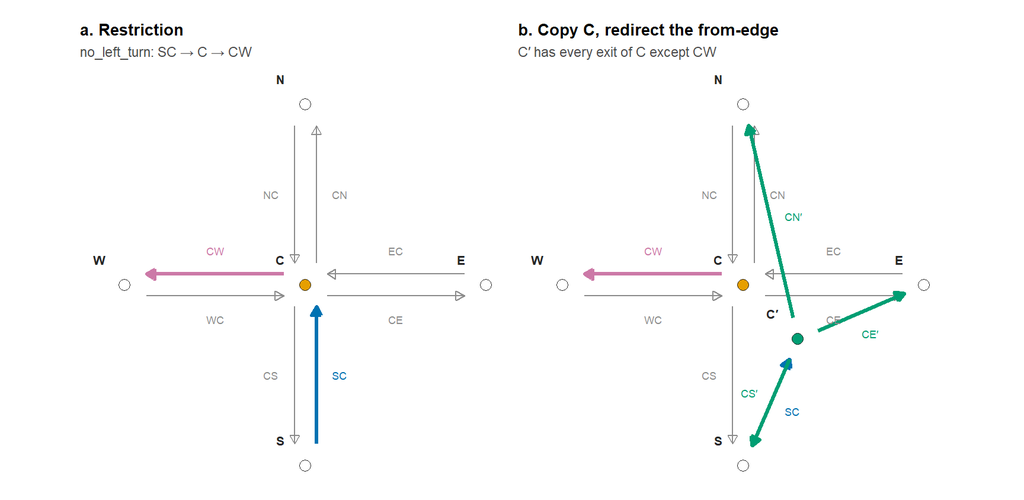

```r
# Reproduces TurnRestrictionModule.processVertex() for a NO_TURN restriction
otp_split <- function(net, from_lab, via_lab, to_lab, offset = c(0.3, -0.3)) {
  n <- st_as_sf(net, "nodes")
  e <- st_as_sf(net, "edges")
  xy <- st_coordinates(n)
  vi <- which(n$label == via_lab)
  new_xy <- xy[vi, ] + offset
  n2 <- rbind(n, st_sf(id = max(n$id) + 1, label = paste0(via_lab, "′"),
                       geometry = st_sfc(st_point(new_xy))))
  ni <- nrow(n2)
  fi <- which(e$label == from_lab)
  st_geometry(e)[fi] <- st_sfc(lane(xy[e$from[fi], ], new_xy, shift = 0))
  e$to[fi] <- ni
  out <- which(e$from == vi & e$label != to_lab)
  copies <- e[out, ]
  copies$label <- paste0(copies$label, "′")
  copies$edge_id <- copies$label
  copies$from <- ni
  st_geometry(copies) <- st_sfc(lapply(copies$to, function(t) {
    lane(new_xy, xy[t, ], shift = 0)
  }))
  e2 <- rbind(e, copies)
  list(net = sfnetwork(n2, e2, directed = TRUE, force = TRUE),
       copies = copies$label)
}

otp <- otp_split(cross, "SC", "C", "CW")
plot_primal(cross, "a. Restriction", "no_left_turn: SC → C → CW",
            roles = roles_left, node_roles = c(C = "via")) |
  plot_primal(otp$net, "b. Copy C, redirect the from-edge",
              "C′ has every exit of C except CW",
              roles = c(roles_left, setNames(rep("copy", length(otp$copies)), otp$copies)),
              node_roles = c(C = "via", "C′" = "copy"))
```

The copied U-turn `CS′` stays in the graph; the search refuses it. `only_*` restrictions work the same way, except the copy keeps only the allowed exit. When several restrictions share a junction, each one is also applied to copies made by earlier ones.

### Via-way restriction: not supported

OTP compares the `via` member with the **node ids** at the ends of the from- and to-edges. A via way’s id never matches, so the restriction finds no edge and is dropped with a `TurnRestrictionBad: "No from edge found"` message. In the toy network above, OTP would allow `A → V → B`.

## 4. OSRM

OSRM builds an **edge-based graph** before routing: one vertex per road segment and one edge per allowed turn. This is the same idea as the line graph in this project. Source: `EdgeBasedGraphFactory`, `WayRestrictionMap`, `RestrictionGraph`, `intersection_analysis.cpp`.

U-turns are only created at dead ends, at barriers and turning circles, where the junction has at most one two-way road or one allowed exit, and where a lane is tagged for U-turns. In the toy junction that keeps the four U-turns at the ends of the arms and none at `C`. The figures in this section use `build_line_graph(..., uturns = uturn_rules(junctions = FALSE))`, which applies the same rule.

### Via-node restriction: the turn is never created

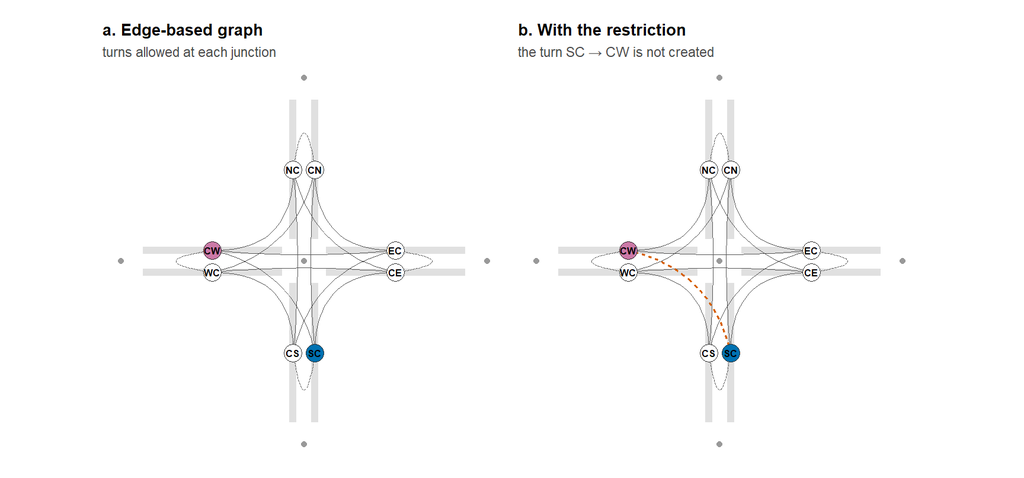

```r
osrm_u <- uturn_rules(junctions = FALSE)
lg_nou <- build_line_graph(toy_edges(cross), none, weights = tt1(cross),
                           uturns = osrm_u)
lg_left <- build_line_graph(toy_edges(cross), r_left, weights = tt1(cross),
                            uturns = osrm_u)
g_nou <- line_graph_sfnet(cross, lg_nou)
plot_line_graph(cross, g_nou, "a. Edge-based graph", "turns allowed at each junction",
                highlight = roles_left) |
  plot_line_graph(cross, line_graph_sfnet(cross, lg_left), "b. With the restriction",
                  "the turn SC → CW is not created",
                  removed = removed_turns(g_nou, lg_left), highlight = roles_left)
```

For `only_*` restrictions, every other turn out of the from-segment is left out instead.

### Via-way restriction: duplicate the via segment’s vertex

OSRM stores via-way restrictions in a **restriction graph**, a tree of restriction paths. Each step along a path gets a **duplicated edge-based node**. The from-segment turns onto the duplicate, and the duplicate has every turn of the original except the banned one.

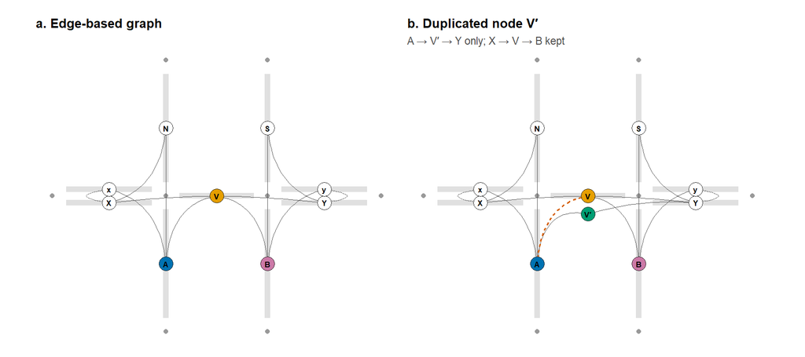

```r
lg_dual0 <- build_line_graph(toy_edges(dual), none, weights = tt1(dual),
                             uturns = osrm_u)
lg_dual <- build_line_graph(toy_edges(dual), r_uturn, weights = tt1(dual),
                            uturns = osrm_u)
g_dual0 <- line_graph_sfnet(dual, lg_dual0)
plot_line_graph(dual, g_dual0, "a. Edge-based graph", highlight = roles_uturn) |
  plot_line_graph(dual, line_graph_sfnet(dual, lg_dual), "b. Duplicated node V′",
                  "A → V′ → Y only; X → V → B kept",
                  removed = removed_turns(g_dual0, lg_dual), highlight = roles_uturn)
```

Restrictions that start with the same steps share the same duplicated nodes, because they share a branch of the restriction graph. Restrictions with several via ways get one duplicate per via segment.

## 5. GraphHopper

GraphHopper routes on the **road network**, but its search moves from edge to edge and pays a cost for every turn, read from a **turn-cost table** keyed by (in-edge, junction, out-edge). A forbidden turn has infinite cost. U-turns get a fixed penalty everywhere (`u_turn_costs`, for example 60 s), which can be set to infinite. `only_*` restrictions are converted into the equivalent `no_*` ones. Source: `RestrictionSetter`, `OSMRestrictionConverter`, `DefaultTurnCostProvider`.

### Via-node restriction: infinite turn cost

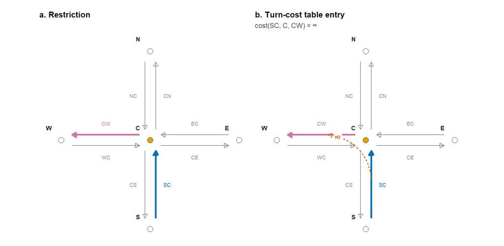

```r
gh_node <- data.frame(from = "SC", to = "CW", label = "∞")
plot_primal(cross, "a. Restriction", roles = roles_left, node_roles = c(C = "via")) |
  plot_turn_costs(cross, gh_node, "b. Turn-cost table entry",
                  "cost(SC, C, CW) = ∞", roles = roles_left,
                  node_roles = c(C = "via"))
```

The network itself does not change: the restriction is one row in the turn-cost table.

### Via-way restriction: an artificial copy of the via edge

GraphHopper adds an **artificial edge** `V′`, a copy of `V` with the same geometry, to the road network. Two infinite turn costs then force traffic from `A` onto the copy and stop the copy from turning onto `B`.

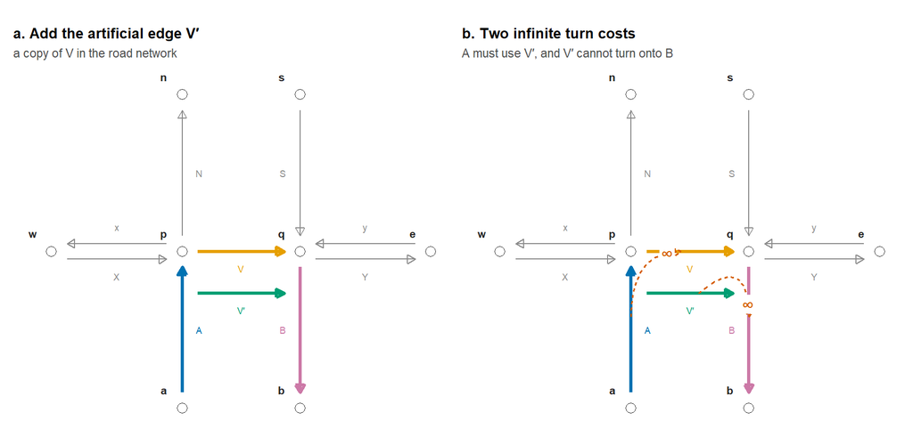

```r
dual_gh <- add_edge_copy(dual, "V", "V′", shift = 0.32)
gh_way <- data.frame(from = c("A", "V′"), to = c("V", "B"), label = "∞")
roles_gh <- c(roles_uturn, "V′" = "copy")
plot_primal(dual_gh, "a. Add the artificial edge V′",
            "a copy of V in the road network", roles = roles_gh) |
  plot_turn_costs(dual_gh, gh_way, "b. Two infinite turn costs",
                  "A must use V′, and V′ cannot turn onto B",
                  roles = roles_gh)
```

```r
knitr::kable(data.frame(
  `In-edge` = c("A", "V′", "any edge", "A"),
  Junction = c("p", "q", "its end", "p"),
  `Out-edge` = c("V", "B", "its reverse", "V′"),
  Cost = c("∞", "∞", "u_turn_costs", "normal"),
  Why = c("A is forced onto the copy", "the copy cannot continue to B",
          "U-turns everywhere", "A → V′ → Y still allowed"),
  check.names = FALSE
))
```

| In-edge | Junction | Out-edge | Cost | Why |
| --- | --- | --- | --- | --- |
| A | p | V | ∞ | A is forced onto the copy |
| V′ | q | B | ∞ | the copy cannot continue to B |
| any edge | its end | its reverse | u_turn_costs | U-turns everywhere |
| A | p | V′ | normal | A → V′ → Y still allowed |

GraphHopper creates one artificial edge per (in-edge, via-edge) pair, so overlapping restrictions that start from the same in-edge share it. Before that, it drops restrictions that contain another one (for example `A → V → B` is redundant if `A → V` is already forbidden). Other roads such as `X` may also turn onto `V′`; that does no harm because `V′` has the same exits as `V` minus `B`, and `V` itself is unchanged.

## 6. This project: line graph with split vertices

We build the line graph explicitly (`build_line_graph()`), like OSRM’s edge-based graph, and run every search on it.

### How this differs from OSRM

The structure is the same as OSRM’s: an edge-based graph built in advance, via-node restrictions as missing turns and via-way restrictions as duplicated vertices. The differences are in the details:

|  | OSRM | This project |
| --- | --- | --- |
| Road segments | consecutive pieces of road between junctions are merged, also across OSM way boundaries when their attributes match | every OSM way is split at nodes shared with another way; pieces are never merged across ways |
| Turn weight | weight of the segment being left + a turn penalty from the profile (angle, traffic signals, U-turns) | half the travel time of each edge + the same OSRM car-profile penalty (`osrm_turn_params()`; `turn_penalty = NULL` turns it off) |
| Route ends | start and end points snapped to partial segments | whole edges |
| U-turns | dead ends, barriers, turning circles, ≤ 1 two-way road, U-turn lanes | dead ends, turning facilities, and junctions of 3+ roads except signalised ones and motorways/trunk roads (`uturn_rules()`) |
| Via-way restrictions | all built at once into a restriction graph; restrictions with a common start share one duplicate | applied one at a time with a search that finds copies; two restrictions from the same edge through the same via make a copy of a copy |
| Conditional restrictions | can be applied (`restriction:conditional`) | skipped |
| Search | contraction hierarchies or multi-level partitioning: milliseconds per query | plain Dijkstra (igraph, dodgr) |

Routes are the same except for the U-turn rule and the first and last edge. The turn penalty follows OSRM’s car profile: an angle term that only applies where more than two roads meet (≈ 0 s straight on, 2.1 s for a right turn, 5.4 s for a left turn), 2 s per traffic signal (at the junction, or inside an edge in its direction of travel) and 20 s per U-turn (none at turning circles). On the Bogotá test area the penalties add a median of 13% to travel times, and change about half of the routes.

Sharing copies between restrictions that start the same way, as OSRM and GraphHopper do, would make our line graph slightly smaller without changing any route.

### Via-node restriction: U-turn rule, then delete the turn

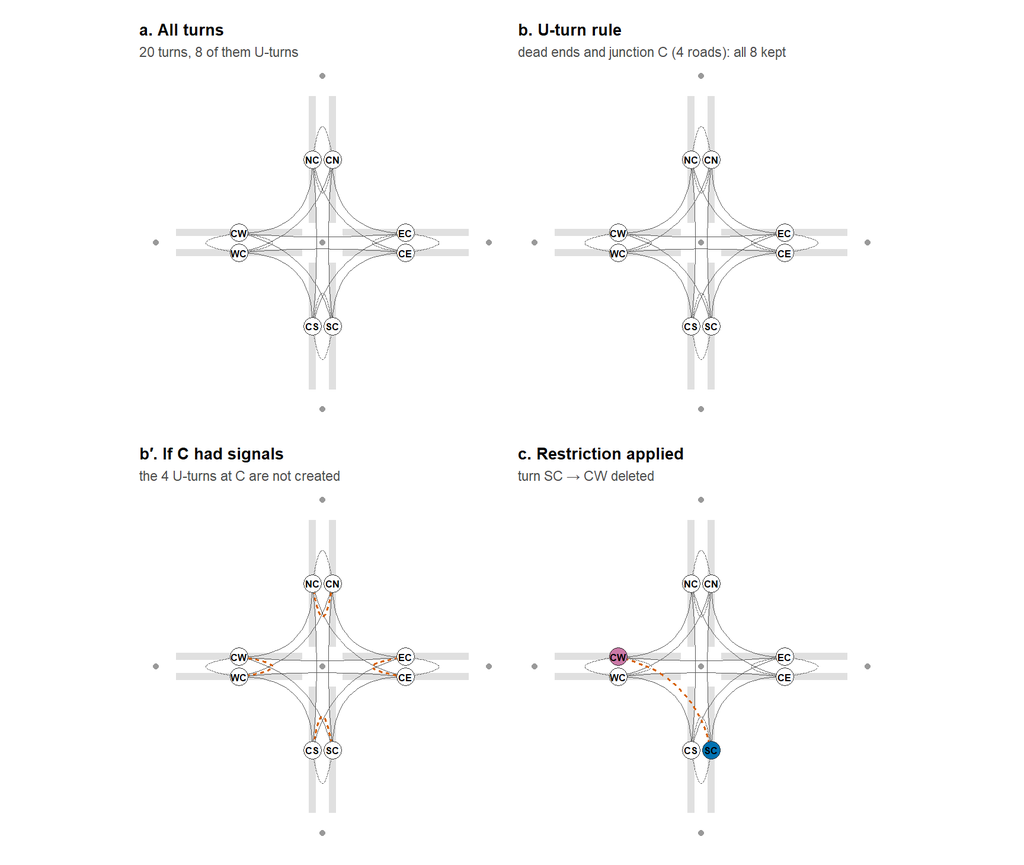

```r
lg_all <- all_turns(cross)
g_all <- line_graph_sfnet(cross, lg_all)
lg_ours0 <- build_line_graph(toy_edges(cross), none, weights = tt1(cross))
g_ours0 <- line_graph_sfnet(cross, lg_ours0)
signal_C <- data.frame(node = 1, highway = "traffic_signals", direction = NA)
lg_sig <- build_line_graph(toy_edges(cross), none, weights = tt1(cross),
                           nodes = signal_C)
lg_ours <- build_line_graph(toy_edges(cross), r_left, weights = tt1(cross))
(plot_line_graph(cross, g_all, "a. All turns", "20 turns, 8 of them U-turns") |
  plot_line_graph(cross, g_ours0, "b. U-turn rule",
                  "dead ends and junction C (4 roads): all 8 kept",
                  removed = removed_turns(g_all, lg_ours0))) /
(plot_line_graph(cross, line_graph_sfnet(cross, lg_sig), "b′. If C had signals",
                  "the 4 U-turns at C are not created",
                  removed = removed_turns(g_all, lg_sig)) |
  plot_line_graph(cross, line_graph_sfnet(cross, lg_ours), "c. Restriction applied",
                  "turn SC → CW deleted",
                  removed = removed_turns(g_ours0, lg_ours), highlight = roles_left))
```

A U-turn here means driving back along the same two-way road. `uturn_rules()` allows it:

- at **dead ends** (the edge has no other exit),
- at **turning circles, turning loops and mini-roundabouts**, without the 20 s U-turn penalty,
- at **junctions of three or more roads**, except at traffic signals (where U-turns are usually not allowed or not practical) and on motorways and trunk roads,
- never in the middle of a road, where only two road pieces meet.

`only_*` restrictions delete every other turn out of the from-edge at that node, U-turns included.

### Via-way restriction: split the via vertex

Deleting the turn `V → B` would also remove the legal `X → V → B` (**b**). Instead, `build_line_graph()` finds the sequence `A → V → B` and gives `A` its own copy of the via vertex, `V′`, with every exit of `V` except `B` (**c**). This is the same result as OSRM’s duplicated node.

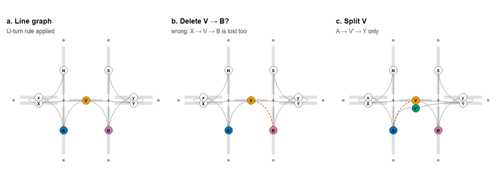

```r
lg_dual0_ours <- build_line_graph(toy_edges(dual), none, weights = tt1(dual))
lg_dual_ours <- build_line_graph(toy_edges(dual), r_uturn, weights = tt1(dual))
g_dual0_ours <- line_graph_sfnet(dual, lg_dual0_ours)
wrong <- lg_dual0_ours
wrong$turns <- wrong$turns[!(from == "V" & to == "B")]
plot_line_graph(dual, g_dual0_ours, "a. Line graph", "U-turn rule applied",
                highlight = roles_uturn) |
  plot_line_graph(dual, line_graph_sfnet(dual, wrong), "b. Delete V → B?",
                  "wrong: X → V → B is lost too",
                  removed = removed_turns(g_dual0_ours, wrong), highlight = roles_uturn) |
  plot_line_graph(dual, line_graph_sfnet(dual, lg_dual_ours), "c. Split V",
                  "A → V′ → Y only",
                  removed = removed_turns(g_dual0_ours, lg_dual_ours),
                  highlight = roles_uturn)
```

### Overlapping restrictions

Two restrictions in a chain, like relations 4297246 and 8868412 in Bogotá: **r1** bans `V → B → C` and **r2** bans `A → V → B`. The to-edge of r2 (`B`) is the via of r1, and the from-edge of r1 (`V`) is the via of r2.

```r
chain <- toy_network(
  nodes = data.frame(id = 1:8,
                     x = c(-1, 0, 1, 1, 0, 2, 0, 2),
                     y = c(0, 0, 0, 1, 1, 1, -1, 0),
                     label = c("a", "p", "q", "s", "t", "u", "w", "e")),
  links = data.frame(
    way = 31:37,
    a = c(1, 2, 3, 4, 4, 2, 3), b = c(2, 3, 4, 5, 6, 7, 8),
    oneway = TRUE, fwd = c("A", "V", "B", "C", "D", "P", "Q"), bwd = NA)
)
r1 <- list(id = 1, restriction = "no_straight_on", from = 32, via = 33, to = 34, via_type = "way")
r2 <- list(id = 2, restriction = "no_left_turn", from = 31, via = 32, to = 33, via_type = "way")
```

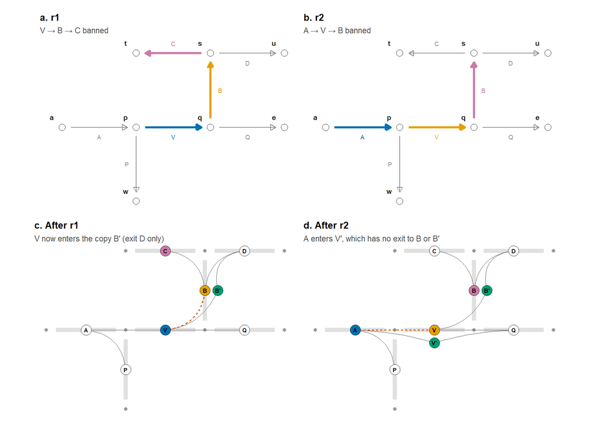

```r
lg_c0 <- build_line_graph(toy_edges(chain), none, weights = tt1(chain))
lg_c1 <- build_line_graph(toy_edges(chain), toy_restrictions(r1), weights = tt1(chain))
lg_c2 <- build_line_graph(toy_edges(chain), toy_restrictions(r1, r2), weights = tt1(chain))
g_c0 <- line_graph_sfnet(chain, lg_c0)

(plot_primal(chain, "a. r1", "V → B → C banned",
             roles = c(V = "from", B = "via", C = "to")) |
   plot_primal(chain, "b. r2", "A → V → B banned",
               roles = c(A = "from", V = "via", B = "to"))) /
  (plot_line_graph(chain, line_graph_sfnet(chain, lg_c1), "c. After r1",
                   "V now enters the copy B′ (exit D only)",
                   removed = removed_turns(g_c0, lg_c1),
                   highlight = c(V = "from", B = "via", C = "to")) |
     plot_line_graph(chain, line_graph_sfnet(chain, lg_c2), "d. After r2",
                     "A enters V′, which has no exit to B or B′",
                     removed = removed_turns(line_graph_sfnet(chain, lg_c1), lg_c2),
                     highlight = c(A = "from", V = "via", B = "to")))
```

After r1, the turn `V → B` points to the copy `B′`. A search for r2’s to-edge that only looks for the original `B` finds nothing, so r2 would be skipped and `A → V → B′` would stay drivable. This was the bug found in Bogotá. The search now matches vertices by road edge, finds `B′`, and r2 splits `V` into `V′`. Passes repeat until nothing changes, and every restriction gets a status:

```r
knitr::kable(lg_c2$report$way_via_status)
```

| relation_id | restriction | splits | status |
| --- | --- | --- | --- |
| 1 | no_straight_on | 1 | applied |
| 2 | no_left_turn | 1 | applied |

### Alternative considered: collapse the via way into one node

Merging the crossover’s ends `p` and `q` into one node `M` turns the restriction into a via-node one. Merging alone lets every entry reach every exit, so it **invents** movements that need `V` driven backwards (`V` is one-way from `p` to `q`). The merged node needs a turn table: the movements that were possible through `V`, minus the banned sequence. We kept vertex splitting because it is a smaller change and keeps `V` in the results.

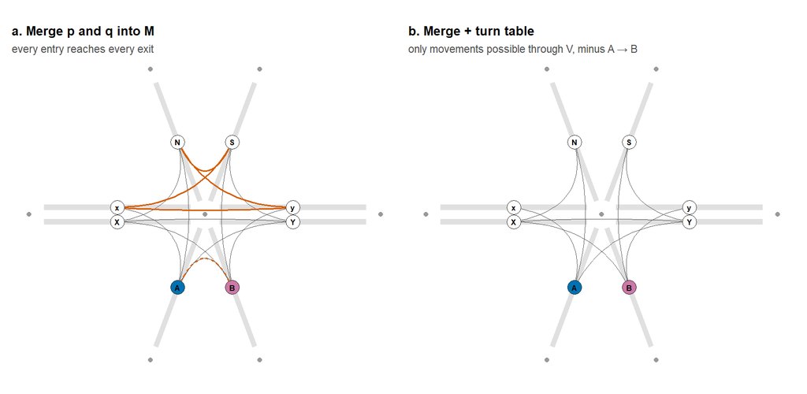

```r
# Movements through the cluster {p, q}: naive merge vs. turn table
collapse_movements <- function(net, lg_base, cluster_nodes, banned_seqs) {
  e <- toy_edges(net)
  internal <- e$edge_id[e$from %in% cluster_nodes & e$to %in% cluster_nodes]
  entries <- e$edge_id[e$to %in% cluster_nodes & !e$edge_id %in% internal]
  exits <- e$edge_id[e$from %in% cluster_nodes & !e$edge_id %in% internal]
  out_by <- split(lg_base$turns$to, lg_base$turns$from)
  paths <- function(a) {          # every path entry -> internal* -> exit
    res <- list(); queue <- list(a)
    while (length(queue)) {
      p <- queue[[1]]; queue <- queue[-1]
      for (nx in out_by[[p[length(p)]]]) {
        if (nx %in% exits) res[[length(res) + 1]] <- c(p, nx)
        if (nx %in% internal && !nx %in% p) queue[[length(queue) + 1]] <- c(p, nx)
      }
    }
    res
  }
  banned <- function(p) any(vapply(banned_seqs, function(s) {
    n <- length(s)
    length(p) >= n && any(vapply(seq_len(length(p) - n + 1), function(i)
      all(p[i:(i + n - 1)] == s), logical(1)))
  }, logical(1)))
  lk <- setNames(e$link_id, e$edge_id)
  mv <- CJ(from = entries, to = exits)[lk[from] != lk[to]]
  mv[, status := vapply(seq_len(.N), function(i) {
    ps <- Filter(function(p) p[length(p)] == to[i], paths(from[i]))
    if (!length(ps)) "invented by merge"
    else if (all(vapply(ps, banned, logical(1)))) "banned"
    else "allowed"
  }, character(1))]
  mv[, via := vapply(seq_len(.N), function(i) {
    ps <- Filter(function(p) p[length(p)] == to[i], paths(from[i]))
    if (length(ps)) paste(ps[[1]], collapse = " → ") else "—"
  }, character(1))]
  mv[]
}

mv <- collapse_movements(dual, lg_dual0, cluster_nodes = c(2, 5),
                         banned_seqs = list(c("A", "V", "B")))

# Draw the merged junction: p and q become one node M, V disappears
merged_net <- function(net, cluster_nodes, label = "M") {
  n <- st_as_sf(net, "nodes")
  e <- st_as_sf(net, "edges")
  xy <- st_coordinates(n)
  m_xy <- colMeans(xy[n$id %in% cluster_nodes, , drop = FALSE])
  keep <- !(e$from %in% which(n$id %in% cluster_nodes) &
              e$to %in% which(n$id %in% cluster_nodes))
  e <- e[keep, ]
  ci <- which(n$id %in% cluster_nodes)
  st_geometry(e) <- st_sfc(lapply(seq_len(nrow(e)), function(i) {
    a <- if (e$from[i] %in% ci) m_xy else xy[e$from[i], ]
    b <- if (e$to[i] %in% ci) m_xy else xy[e$to[i], ]
    two <- any(e$link_id == e$link_id[i] & e$edge_id != e$edge_id[i])
    lane(a, b, shift = if (two) 0.06 else 0)
  }))
  n2 <- n[-ci[-1], ]
  st_geometry(n2)[n2$id == cluster_nodes[1]] <- st_sfc(st_point(m_xy))
  n2$label[n2$id == cluster_nodes[1]] <- label
  e$from <- match(n$id[e$from], n2$id); e$from[is.na(e$from)] <- which(n2$label == label)
  e$to <- match(n$id[e$to], n2$id); e$to[is.na(e$to)] <- which(n2$label == label)
  sfnetwork(n2, e, directed = TRUE, force = TRUE)
}

mnet <- merged_net(dual, c(2, 5))
mv_lg <- list(
  vertices = data.table(vertex_id = st_as_sf(mnet, "edges")$edge_id,
                        edge_id = st_as_sf(mnet, "edges")$edge_id),
  turns = mv[, .(from, to, turn_type = "turn")]
)
g_m <- line_graph_sfnet(mnet, mv_lg)
gm_e <- st_as_sf(g_m, "edges")
status_of <- setNames(mv$status, paste(mv$from, mv$to))
gm_e$status <- status_of[paste(gm_e$from_id, gm_e$to_id)]
g_table <- line_graph_sfnet(mnet, list(vertices = mv_lg$vertices,
  turns = mv[status == "allowed", .(from, to, turn_type = "turn")]))

plot_line_graph(mnet, g_m, "a. Merge p and q into M",
                "every entry reaches every exit",
                invented = gm_e[gm_e$status == "invented by merge", ],
                removed = gm_e[gm_e$status == "banned", ],
                highlight = c(A = "from", B = "to")) |
  plot_line_graph(mnet, g_table, "b. Merge + turn table",
                  "only movements possible through V, minus A → B",
                  highlight = c(A = "from", B = "to"))
```

Solid orange arrows in **a** are movements that do not exist in the real network; the dashed one is the banned `A → V → B`.

```r
knitr::kable(mv[order(status, from, to),
                .(Movement = paste(from, "→", to), `Path in the real network` = via,
                  Status = status)])
```

| Movement | Path in the real network | Status |
| --- | --- | --- |
| A → N | A → N | allowed |
| A → Y | A → V → Y | allowed |
| A → x | A → x | allowed |
| S → B | S → B | allowed |
| S → Y | S → Y | allowed |
| X → B | X → V → B | allowed |
| X → N | X → N | allowed |
| X → Y | X → V → Y | allowed |
| y → B | y → B | allowed |
| A → B | A → V → B | banned |
| S → N | — | invented by merge |
| S → x | — | invented by merge |
| y → N | — | invented by merge |
| y → x | — | invented by merge |

## Summary

|  | OpenTripPlanner | OSRM | GraphHopper | This project |
| --- | --- | --- | --- | --- |
| Graph stored | primal (road network) | line graph (edge-based graph) | primal + turn-cost table | line graph |
| Graph searched | primal; each step remembers the last edge | line graph | line graph, worked out during the search | line graph |
| Via node | copy the junction node (§3) | turn not created (§4) | infinite turn cost (§5) | turn deleted (§6) |
| Via way | not supported | duplicated edge-based node (§4) | artificial copy of the via edge + infinite turn costs (§5) | copy of the via vertex (§6) |
| `only_*` | the copy keeps only the allowed exit | other turns not created | converted to equivalent `no_*` | other turns deleted; the copy keeps only the chain |
| Overlapping restrictions | restrictions also applied to earlier copies | shared branches of the restriction graph | one artificial edge per (in-edge, via-edge) pair; redundant restrictions dropped | search finds copies; passes repeat until stable |
| U-turns | never allowed | dead ends, barriers, turning circles, ≤ 1 two-way road, U-turn lanes | fixed penalty everywhere (e.g. 60 s, or infinite) | dead ends, turning facilities, unsignalised junctions (§6) |